# AI in the workplace - Appendix A

## Assigning task labels

An alternative approach is to manually assign labels to the verbs to identify if a task is possible to automate. We then look at the proportion of verbs in a role that have been assigned "automatable == True" to predict the proportion to which a role can be automated.

### Assigning an automation label to groups of verbs

```python
#CLUSTER THE VERBS INTO 50 GROUPS
kmeans = KMeans(n_clusters=50, random_state=7,init ='k-means++')
labels = kmeans.fit_predict(get_word_vectors(verbs_list))
```

```python
#EXPORT TO A CSV TO ALLOW CATGORIES TO BE MANUALLY ASSIGNED USING EXCEL
df_clusters = pd.DataFrame({'Verbs':verbs_list,'Category':labels})
df_clusters.groupby(['Category'])['Verbs'].apply(' '.join).reset_index().to_csv('verbcats.csv', sep=',')
```

```python
# After updating the table in excel reload it
df_clusters_update=pd.read_csv('/Users/MacUser/Dropbox/Study/Imperial/WA/Assignment 2/verbcats2.csv', sep=',')
bow = df_clusters_update.groupby(['Automate'])['Verbs'].apply(' '.join).reset_index()

#create a bag of words that indicate the ability to automate.
bow_true = bow.loc[1, 'Verbs'].split()
bow_false = bow.loc[0, 'Verbs'].split()
```

### Once we generate a BOW we can perform a count

```python
#define a function to calculate the automatability of a role

def bowcount(verbs):
    truecount = 0
    falsecount = 0
    for verb in verbs:
        if verb in bow_true:
            truecount+=1
        elif verb in bow_false:
            falsecount+=1
    if truecount+falsecount>0:
        automate=100*(round(truecount/(truecount+falsecount),2))
    else:
        automate=np.nan
    return(automate)

# Apply the above function to the datatable
roles['automate'] = roles.apply(lambda roles: bowcount(roles['verbs']),axis=1)
```

### Visualise the results

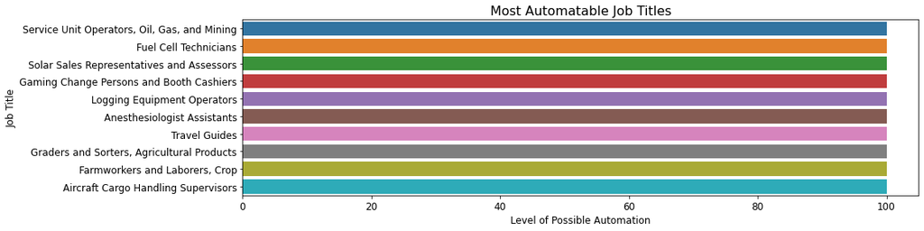

```python
#Generate the histogram of the most automatable roles
roles.sort_values('automate', ascending=False,inplace=True)
plt.figure(figsize=(15,4))
sns.barplot(x='automate',y='Title', data = roles[0:10].reset_index())
plt.xlabel("Level of Possible Automation")
plt.ylabel("Job Title")
plt.title("Most Automatable Job Titles", loc='center', fontsize = 16)
plt.show()
```

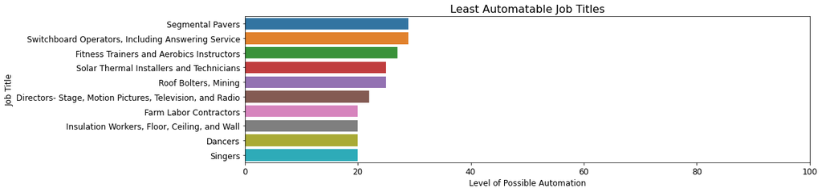

```python
#Generate the histogram of the least automatable roles
roles.sort_values('automate', ascending=False,inplace=True)
plt.figure(figsize=(15,4))
sns.barplot(x='automate',y='Title', data = roles[len(roles)-10:len(roles)].reset_index())
plt.xlabel("Level of Possible Automation")
plt.ylabel("Job Title")
plt.xlim(0, 100)
plt.title("Least Automatable Job Titles", loc= 'center', fontsize = 16)
plt.show()
```

```python
import scattertext as st

roles['highly_automatable'] = np.where(roles['automate']>=70,'Y','N')

df = roles.assign(
        parse=lambda df: df.verb_string.apply(st.whitespace_nlp_with_sentences))

corpus = st.CorpusFromParsedDocuments(
    df, category_col='highly_automatable', parsed_col= 'parse'
).build().get_unigram_corpus().compact(st.AssociationCompactor(2000))

html = st.produce_scattertext_explorer(
    corpus,
    category='Y', category_name='High automation', not_category_name='Low automation',
    minimum_term_frequency=0, pmi_threshold_coefficient=0,
    width_in_pixels=1000, metadata=corpus.get_df()['Task'],
    transform=st.Scalers.dense_rank
)
open('./roles.html', 'w').write(html)

#from IPython.display import HTML
#HTML(filename='./roles.html')
```

```
2786074
```

## Segregating types of automation

A more sophisticated approach is to use the competencies defined by Amador Diaz Lopez to investigate the relationship between competencies and AI-related technologies. Here a list of words is provided that indicate where AI can be applied to support a role:

- Repetitive: Data Wrangling, Dynamic Optimization.
- Research: Dynamic Optimization, Unsupervised Learning.
- Standardised: Data Wrangling, Supervised Learning.
- Analysis: Supervised Learning, Unsupervised Learning.

### Create the competency definitions

```python
# Define the word lists for each competency

Repetitive = ['furthered', 'administered', 'compiled', 'categorized', 'distributed', 'catalogued', 'familiarize',
             'responded', 'corresponded', 'reviewed', 'adapted', 'approved', 'validated', 'cared-for',
             'screened', 'incorporated', 'submitted', 'registered', 'prepared', 'recorded', 'ensured',
             'coded', 'filed', 'organized', 'operated', 'assessed', 'classified', 'charted', 'clarified',
             'logged', 'assisted', 'advocated', 'executed', 'verified', 'collected', 'set-up', 'scheduled',
             'expedited', 'answered', 'supported', 'ordered', 'processed', 'purchased', 'generated', 'systematized',
             'reserved', 'demonstrated', 'facilitated', 'supplied', 'arranged', 'insured', 'obtained', 'updated',
             'aided', 'generated', 'provided']

Research = ['experimented', 'diagnosed', 'inspected', 'summarized', 'formulated', 'examined', 'modified',
            'conducted', 'interpreted', 'solved', 'searched', 'invented', 'tested', 'located', 'calculated',
            'determined', 'clarified', 'gathered', 'extracted', 'compared', 'surveyed', 'measured', 'organized',
            'researched', 'detected', 'investigated', 'computed', 'interviewed', 'collected', 'explored']

Analysis = ['determined', 'estimated', 'appraised', 'developed', 'managed', 'resolved', 'spearheaded',
            'utilized', 'transformed', 'reconciled', 'modelled', 'retrieved', 'integrated', 'shaped',
            'assessed', 'surpassed', 'solved', 'critique', 'balanced', 'corrected', 'measured', 'audited',
            'restored', 'reduced', 'researched', 'projected', 'monitored', 'marketed', 'engineered',
            'programmed', 'analysed', 'reduced', 'identified', 'planned', 'evaluated', 'forecast', 'conserved']

Standardized = ['converted', 'installed', 'administered', 'calculated', 'facilitated', 'clarified',
                'maintained', 'conserved', 'planned', 'adjusted', 'restored', 'scheduled', 'operated',
                'tested', 'followed', 'rectified', 'overhauled', 'built', 'remodelled', 'fortified',
                'simplified', 'regulated', 'displayed', 'replaced', 'repaired', 'upgraded', 'printed',
                'assembled', 'specialized', 'studied', 'adapted', 'allocated', 'computed', 'debugged', 'constructed']
```

```python
# Convert the above lists to a lemmatized string

def list_to_lemma(word_list):
    word_string= ' '.join(word_list)
    doc = nlp(word_string)
    lemma_words = [w.lemma_ for w in doc]
    lemma_string= ' '.join(lemma_words)
    return(lemma_string)

Repetitive_words=list_to_lemma(Repetitive)
Research_words=list_to_lemma(Research)
Analysis_words=list_to_lemma(Analysis)
Standardized_words=list_to_lemma(Standardized)
```

### Process the jobs dataset and determine similarity to competencies

While this analysis can be performed at task, role or group level for ease of processing and visualisation we have decided to evaluate at the level of role group as defined by the first 2 characters of the O*NET SOC CODE

Using the functions defined earlier the tasks are processed and the similarity with the above competencies determined.

```python
jobs.head()
```

|  | O*NET-SOC Code | Title | Task ID | Task | Task Type | Incumbents Responding | Date | Domain Source | Main Task Verb |
| --- | --- | --- | --- | --- | --- | --- | --- | --- | --- |
| 0 | 11-1011.00 | Chief Executives | 8823 | Direct or coordinate an organization's financi... | Core | 87.0 | 07/2014 | Incumbent | Direct |
| 1 | 11-1011.00 | Chief Executives | 8831 | Appoint department heads or managers and assig... | Core | 87.0 | 07/2014 | Incumbent | Appoint |
| 2 | 11-1011.00 | Chief Executives | 8825 | Analyze operations to evaluate performance of ... | Core | 87.0 | 07/2014 | Incumbent | Analyze |
| 3 | 11-1011.00 | Chief Executives | 8826 | Direct, plan, or implement policies, objective... | Core | 87.0 | 07/2014 | Incumbent | Direct, |
| 4 | 11-1011.00 | Chief Executives | 8827 | Prepare budgets for approval, including those ... | Core | 87.0 | 07/2014 | Incumbent | Prepare |

```python
# Apply the get verbs function
jobs['verbs'] = jobs.apply(lambda jobs: get_verbs(jobs['Task']),axis=1)

# Apply the 'list_to_string' function on the verbs
jobs['verb_string'] = jobs.apply(lambda jobs: list_to_string(jobs['verbs']),axis=1)

#Extract the first 2 digits in the O*NET-SOC Code
jobs['O*NET_cat']=jobs['O*NET-SOC Code'].str[:2].astype(int)


# Apply a catagory based on the above O*NET-SOC Code
jobs['Group'] = pd.cut(
    jobs['O*NET_cat'],
    [-np.inf, 14,20,28,30,40,42,44,46,48,50,52,54, np.inf],
    labels=['Management', 'Engineering /Science', 'Education','Healthcare','Service','Sales','Admin','Farming','Construction','Installation','Production','Transportation','Military']
)


# Group the verbs
job_cats = jobs.groupby(['Group'])['verb_string'].apply(' '.join).reset_index()

job_cats.set_index('Group', inplace=True)

#Noting that there are no verbs for the military Group we drop this row
job_cats.drop('Military',inplace=True)

job_cats=job_cats.reset_index()

# Apply the 'find_similarity' function to determine which category best suits each role
job_cats['Repetitive'] = job_cats.apply(lambda job_cats: find_similarity(Repetitive_words,job_cats['verb_string']),axis=1)
job_cats['Research'] = job_cats.apply(lambda job_cats: find_similarity(Research_words,job_cats['verb_string']),axis=1)
job_cats['Analysis'] = job_cats.apply(lambda job_cats: find_similarity(Analysis_words,job_cats['verb_string']),axis=1)
job_cats['Standardized'] = job_cats.apply(lambda job_cats: find_similarity(Standardized_words,job_cats['verb_string']),axis=1)

job_cats
```

|  | Group | verb_string | Repetitive | Research | Analysis | Standardized |
| --- | --- | --- | --- | --- | --- | --- |
| 0 | Management | fund maximize increase appoint assign analyze ... | 0.950402 | 0.904386 | 0.926172 | 0.891851 |
| 1 | Engineering /Science | analyze develop apply create apply assign sche... | 0.948831 | 0.923506 | 0.937195 | 0.909456 |
| 2 | Education | maintain assist confer evaluate determine deve... | 0.948693 | 0.886726 | 0.892363 | 0.883275 |
| 3 | Healthcare | evaluate diagnose perform correct obtain recor... | 0.944830 | 0.905846 | 0.913748 | 0.894698 |
| 4 | Service | maintain report discuss provide bathe care ent... | 0.949522 | 0.876178 | 0.890246 | 0.891437 |
| 5 | Sales | provide direct examine ensure monitor ensure i... | 0.956328 | 0.884568 | 0.894166 | 0.873077 |
| 6 | Admin | supervise ensure resolve answer provide verify... | 0.970575 | 0.893245 | 0.884431 | 0.892322 |
| 7 | Farming | monitor ensure monitor identify solve improve ... | 0.925100 | 0.871110 | 0.892769 | 0.905075 |
| 8 | Construction | supervise coordinate schedule read determine p... | 0.891899 | 0.816470 | 0.851040 | 0.905048 |
| 9 | Installation | determine inspect monitor examine provide prev... | 0.877901 | 0.840940 | 0.857006 | 0.927576 |
| 10 | Production | enforce coordinate confer coordinate plan esta... | 0.910157 | 0.850321 | 0.874792 | 0.914973 |
| 11 | Transportation | determine compute train distribute maximize c... | 0.941523 | 0.863637 | 0.884633 | 0.904832 |

The data is then normalised to make it more interpretable on a chart

```python
# Obtain the groups and standardise the values
y=job_cats['Group']

X= job_cats.drop(['verb_string','Group'], axis=1)
X = StandardScaler().fit_transform(X)
df2= pd.DataFrame(data=X,columns=['Repetitive','Research','Analysis','Standardized'])
df2['Group'] = y

df2.head()
```

|  | Repetitive | Research | Analysis | Standardized | Group |
| --- | --- | --- | --- | --- | --- |
| 0 | 0.591348 | 0.966827 | 1.433689 | -0.541296 | Management |
| 1 | 0.532377 | 1.627651 | 1.890109 | 0.709719 | Engineering /Science |
| 2 | 0.527202 | 0.356485 | 0.033800 | -1.150654 | Education |
| 3 | 0.382199 | 1.017299 | 0.919268 | -0.338991 | Healthcare |
| 4 | 0.558327 | -0.008044 | -0.053842 | -0.570674 | Service |

### Display the information

By visualising this data we can easily observe that:

- Installation and production offer the greatest opportunity for standardising thorough leveraging Data Wrangling and Supervised Learning technologies.
- Management and Engineering are involve research and analysis and could tehrefore benefit from effective adoption of supervised learning and unsupervised Learning technologies.
- Admin and sales tasks are more repetitive type functions that could benefit from effective data wrangling and dynamic optimization.

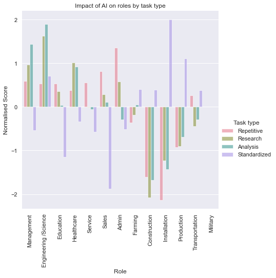

```python
#Tidy the datatable
tidy = df2.melt(id_vars=['Group'], value_vars=['Repetitive','Research','Analysis','Standardized'])

# Draw a nested barplot
sns.set(rc={'figure.figsize':(11.7,8.27)})

g =sns.catplot(
    data=tidy, kind="bar",
    x="Group", y="value", hue="variable",
    ci="sd", palette="husl", alpha=.6, height=6
)
g.despine(left=True)
g.set_axis_labels("", "Score")
g.legend.set_title("Task type")
#g.fig.suptitle('Impact of AI on roles by task type')
for axes in g.axes.flat:
    axes.set_xticklabels(axes.get_xticklabels(), rotation=90)

plt.xlabel("Role")
plt.ylabel("Normalised Score")
plt.title('Impact of AI on roles by task type', loc='center', size=12)

plt.show()
```

## Conclusions

From grouping by technologies and competencies, we notice that installation and production offer the greatest opportunity for standardising, thorough leveraging Data Wrangling and Supervised Learning technologies. Management and engineering involve research and analysis and could therefore benefit from effective adoption of supervised learning and unsupervised learning technologies. Admin and sales tasks are more repetitive type functions that could benefit from effective data wrangling and dynamic optimization.

## References

Agrawal, A. (2018) Prediction Machines: The Simple Economics of Artificial Intelligence, p. 66